# An mTurk study examining hte link between temporal discounting and abstraction

I’m interested in the link between temporal discounting and abstraction.

This is a follow-up of an earlier analysis where our result didn’t come out at all the way we were hoping.

I wanted to re-do the analysis with some improvements to see if we can better detect the effect through improving the quality of our dataset.

## Construal level

For this study, we want to test this predictions relevant to construal level:

1. A Construal Level manipulation has an effect on temporal discounting, such that more abstract construal level manipulations predict lower rates of temporal discounting
1. This relationship will be observable with random construal order
2. This relationship will be observable with the abstract to concrete and the concrete to abstract construal order conditions, OR
3. This relationship will only be observable in the direction observed by Yi et al. (2017), i.e., only among participants who view the concrete condition prior to the abstract prediction
4. This relationship will be observable in the interleaved conditions
5. This relationship will be observable in the blocked conditions

# Available data

In our algorithm, we have a discounting parameter, $k$, which indicates how much subjects prefer a reward immediately rather than later. With every trial we try to use our ‘best estimate’ of their discount rate to present a choice they’ll be indifferent to, in order to best gather information about their tipping point.

I followed a prior analysis method to start off with a ‘default’ k value and then use a very simple algorithm which estimates a better discount rate - simply adjusts it up by 33% or down by 33% until we reach a trade-off point, so we get a graph like

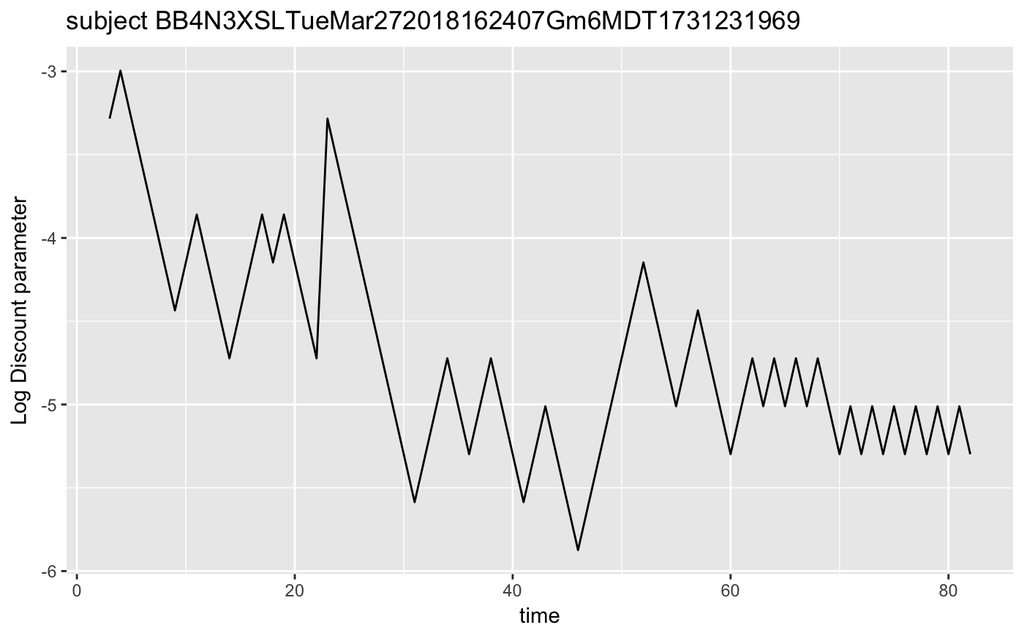

```r
subject.to.show<-unique(data.itc[ConditionCode=="BB4N3XSL", SubjectUniqueID])[[9]]
ggplot(data.itc[SubjectUniqueID==subject.to.show],
       aes(x=TrialId,y=log(endingK)))+
  geom_line()+
  labs(y="Log Discount parameter",x="time",title=paste0("subject ",subject.to.show))
```

So there is theoretically a constant discounting parameter each subject has, yet we have a varying discount parameter we use to try to set an indifference point. Subjects theoretically have a constant discount rate and responses that differ according to that function, plus noise. So in trials where the ‘provisional’ k value used to set the indifference point (“|logStartingK|”) is higher, it’ll be higher *relative to subject’s true discount rate* and thus, the higher that provisional kvalue is, the more we’ll get LargerLater choices. Does this bear out?

# Preliminary analyses

Do subjects stabilize their learning rates? That seems like important information to validate what we’re doing. We can measure this by adding an index at each point which indicates the number of previous consecutive trials with teh same choice as the current trial. This should theoretically converge to close to 0 as we go through. the task.

```
Call:
lm(formula = ConsecutiveChoices ~ TrialIdItcSC, data = data.itc[TrialIdItcSC <=
    40])

Residuals:
   Min     1Q Median     3Q    Max
-6.343 -4.982 -3.292  1.250 63.663

Coefficients:
              Estimate Std. Error t value Pr(>|t|)
(Intercept)   7.368877   0.143834  51.232  < 2e-16 ***
TrialIdItcSC -0.025787   0.006108  -4.222 2.44e-05 ***
---
Signif. codes:  0 ‘***’ 0.001 ‘**’ 0.01 ‘*’ 0.05 ‘.’ 0.1 ‘ ’ 1

Residual standard error: 9.075 on 16626 degrees of freedom
Multiple R-squared:  0.001071,  Adjusted R-squared:  0.001011
F-statistic: 17.82 on 1 and 16626 DF,  p-value: 2.438e-05

Analysis of Variance Table

Model 1: ConsecutiveChoices ~ TrialIdItcSC
Model 2: ConsecutiveChoices ~ TrialIdItcSC + I(TrialIdItcSC^2)
  Res.Df     RSS Df Sum of Sq     F    Pr(>F)
1  11518 1078533
2  11517 1076410  1    2123.4 22.72 1.898e-06 ***
---
Signif. codes:  0 ‘***’ 0.001 ‘**’ 0.01 ‘*’ 0.05 ‘.’ 0.1 ‘ ’ 1

Call:
lm(formula = ConsecutiveChoices ~ TrialIdItcSC + I(TrialIdItcSC^2),
    data = data.no.missing)

Residuals:
   Min     1Q Median     3Q    Max
-6.288 -4.996 -3.231  0.769 64.788

Coefficients:
                    Estimate Std. Error t value Pr(>|t|)
(Intercept)        6.3650353  0.2843153  22.387  < 2e-16 ***
TrialIdItcSC       0.1154039  0.0319815   3.608 0.000309 ***
I(TrialIdItcSC^2) -0.0036057  0.0007565  -4.766  1.9e-06 ***
---
Signif. codes:  0 ‘***’ 0.001 ‘**’ 0.01 ‘*’ 0.05 ‘.’ 0.1 ‘ ’ 1

Residual standard error: 9.668 on 11517 degrees of freedom
Multiple R-squared:  0.00346,   Adjusted R-squared:  0.003287
F-statistic:    20 on 2 and 11517 DF,  p-value: 2.143e-09
```

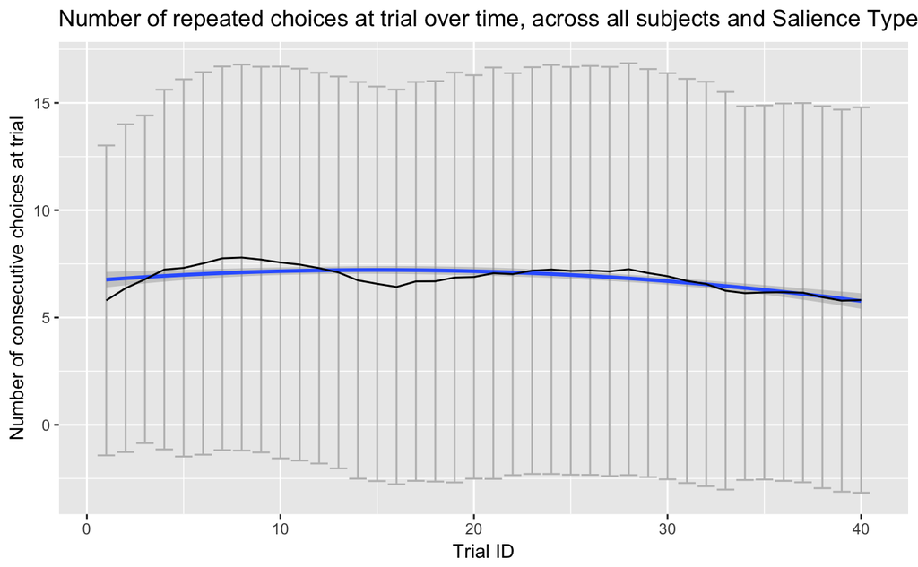